### 7월/3주

#### ▶ ▣ 정당지지도 ▣

더불어민주당 43.9%, 국민의힘 36.5%, 정의당 2.2%, 기타 정당 2.1%, 지지하는 정당이 없다 14.6%, 잘 모르겠다 0.6%

#### ▶ ▣ 대통령 국정 수행 평가 ▣

잘하고 있다 38.3%, 잘못하고 있다 59.5%, 잘 모르겠다 2.1%

#### ☑ ▣ 내년 총선 지지방향 ▣

원활한 국정수행을 뒷받침하기 위해 여당에 힘을 실어 줘야 한다 38.8%, 현 정권 견제를 위해서 제1야당인 민주당에 힘을 실어 줘야 한다 46.3%, 기존 양당이 아닌 제3세력에 힘을 실어 줘야 한다 14.9%

#### ☑ ▣ 서울-양평 고속도로 국정조사 찬반 ▣

국정조사 추진에 찬성한다 63.7%, 국정조사 추진에 반대한다 31.6%, 잘 모르겠다 4.7%

#### ☑ ▣물가 인상 체감도(합) ▣

체감한다(합) 82.8%, 체감하지 않는다(합) 15.8%, 잘 모르겠다 1.4%

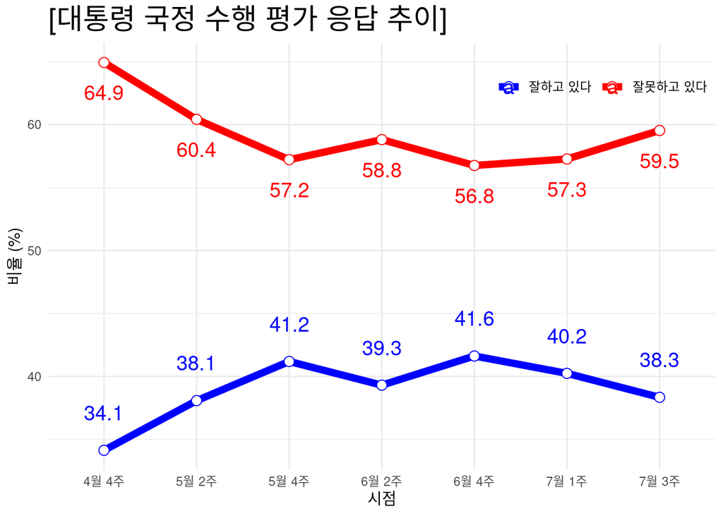

[figure not shown]

### 추가사항

- [주요질문 / 집단별 세부통계 보기](https://modernity.shinyapps.io/survey_str/) (링크누르시오)

### 참고사항

- 표본수는 2,025명,표본오차는 95% ±2.2%p
- [중앙선거여론조사심의위원회](https://nesdc.go.kr/portal/bbs/B0000005/list.do?menuNo=200467)에서 관련사항 확인가능

2023.07.20 (목) 09:00 제작

- 연구개발 단계입니다.
- 순위별 최빈 단어 기준의 분류기법입니다.
- 제공: 감동과 마음의 [조원씨앤아이](http://jowoncni.com/html/index.html)